# Predicting Heart Disease using Machine Learning

## 1. Problem Definition

The problem we are exploring is an example of **binary classification**.

> Given the clinical data about a patient, this model is going to help in classifying whether the patient has a heart disease or not.

The objective of this notebook is to train a machine learning model to identify patients with heart disease based on the given data.

## 2. Data

The original data came from the Cleveland database from UCI Machine Learning Repository.

Howevever, we've downloaded it in a formatted way from Kaggle.

The original database contains 76 attributes, but here only 14 attributes will be used. Attributes (also called features) are the variables what we'll use to predict our target variable.

We use the independent variables to predict our dependent variable.

Or in our case, the independent variables are a patients different medical attributes and the dependent variable is whether or not they have heart disease.

## 3. Evaluation

If this machine learning model achieves 95% accuracy at predicting whether or not a person has heart diesase during the concept of proof, we will pursue this project.

## 4. Features

### Data Dictionary:

1. **age** - age in years
2. **sex** - (1 = male, 0 = female)
3. **cp** - chest pain type:
   - 0 - Typical angina : chest pain related to decreased blood supply to the heart
   - 1 - Atypical angina : chest pain not related to heart
   - 2 - Non-anigal pain : typically esophageal spasms (non heart related)
   - 3 - Asymptomatic : chest pain not showing signs of disease
4. **trestbps** - resting blood pressure (meassured in mm of Hg on admission to the hospital)
   - anything above 130-140 is typically a cause for concern
5. **serum cholestoral in mg/dl**
   - serum = LDL + HDL + 0.2 * triglycerides
   - above 200 is a cause for concern
6. **fbs** - (fasting blood sugar > 120 mg/dl) (1 = true, 0 = false)
   - '> 126 mg/dl' signifies diabetes
7. **restecg** -resting electrocardiographic results
   - 0 - nothing to note
   - 1 - ST-T wave abnormality
     - can range from mild symptoms to severe problems
     - signals non-normal heart beat
   - 2 - Possible or definite left ventricle hypertrophy
     - enlarged heart's main pumping chamber
8. **thalach** - maximum heart rate achieved
9. **exang** - excercise induce angina (1 = yes, 0 = no)
10. **oldpeak** - ST depression induced by excercise relative to rest
    - looks at stress of heart during excercise
    - unhealthy heart will stress more
11. **slope** - the slope of the peak excercise ST segment
    - 0 - Upsloping: better heart rate with excercise (uncommon)
    - 1 - Flatsloping: minimal change (typical healthy heart)
    - 2 - Downsloping: signs of unhealthy heart
12. **ca** - number of major vessels (0-3) colored by flourosopy
    - coloured vessels means the doctor can see the blood passing through
    - the more blood movement the better (no clots)
13. **thal** - thalium stress result
    - 1-3 - normal
    - 6 - fixed defect: used to be defect but now ok
    - 7 - reversible defect: no proper blood movement while excercising
14. **target** - have heart diesase or not (1 = yes, 0 = no)(= predicted attribute)

**Note:** no personal identifiable information is available in the dataset

## 5. Preparing the tools

```python
import numpy as np
import pandas as pd
import matplotlib.pyplot as plt
import seaborn as sns

%matplotlib inline

from sklearn.linear_model import LogisticRegression
from sklearn.ensemble import RandomForestClassifier
from sklearn.neighbors import KNeighborsClassifier

from sklearn.model_selection import train_test_split, cross_val_score
from sklearn.model_selection import RandomizedSearchCV, GridSearchCV
from sklearn.metrics import confusion_matrix, ConfusionMatrixDisplay
from sklearn.metrics import classification_report, accuracy_score, f1_score, precision_score, recall_score
from sklearn.metrics import RocCurveDisplay

import time
print(f"last updated: {time.asctime()}")
```

```
last updated: Mon Dec 18 19:37:41 2023
```

## 6. Exploratory Data Analysis

### Loading the data

```python
df = pd.read_csv("./Data/heart-disease.csv")
df.shape
```

```
(303, 14)
```

```python
df.head()
```

|  | age | sex | cp | trestbps | chol | fbs | restecg | thalach | exang | oldpeak | slope | ca | thal | target |
| --- | --- | --- | --- | --- | --- | --- | --- | --- | --- | --- | --- | --- | --- | --- |
| 0 | 63 | 1 | 3 | 145 | 233 | 1 | 0 | 150 | 0 | 2.3 | 0 | 0 | 1 | 1 |
| 1 | 37 | 1 | 2 | 130 | 250 | 0 | 1 | 187 | 0 | 3.5 | 0 | 0 | 2 | 1 |
| 2 | 41 | 0 | 1 | 130 | 204 | 0 | 0 | 172 | 0 | 1.4 | 2 | 0 | 2 | 1 |
| 3 | 56 | 1 | 1 | 120 | 236 | 0 | 1 | 178 | 0 | 0.8 | 2 | 0 | 2 | 1 |
| 4 | 57 | 0 | 0 | 120 | 354 | 0 | 1 | 163 | 1 | 0.6 | 2 | 0 | 2 | 1 |

```python
df.head(10)
```

|  | age | sex | cp | trestbps | chol | fbs | restecg | thalach | exang | oldpeak | slope | ca | thal | target |
| --- | --- | --- | --- | --- | --- | --- | --- | --- | --- | --- | --- | --- | --- | --- |
| 0 | 63 | 1 | 3 | 145 | 233 | 1 | 0 | 150 | 0 | 2.3 | 0 | 0 | 1 | 1 |
| 1 | 37 | 1 | 2 | 130 | 250 | 0 | 1 | 187 | 0 | 3.5 | 0 | 0 | 2 | 1 |
| 2 | 41 | 0 | 1 | 130 | 204 | 0 | 0 | 172 | 0 | 1.4 | 2 | 0 | 2 | 1 |
| 3 | 56 | 1 | 1 | 120 | 236 | 0 | 1 | 178 | 0 | 0.8 | 2 | 0 | 2 | 1 |
| 4 | 57 | 0 | 0 | 120 | 354 | 0 | 1 | 163 | 1 | 0.6 | 2 | 0 | 2 | 1 |
| 5 | 57 | 1 | 0 | 140 | 192 | 0 | 1 | 148 | 0 | 0.4 | 1 | 0 | 1 | 1 |
| 6 | 56 | 0 | 1 | 140 | 294 | 0 | 0 | 153 | 0 | 1.3 | 1 | 0 | 2 | 1 |
| 7 | 44 | 1 | 1 | 120 | 263 | 0 | 1 | 173 | 0 | 0.0 | 2 | 0 | 3 | 1 |
| 8 | 52 | 1 | 2 | 172 | 199 | 1 | 1 | 162 | 0 | 0.5 | 2 | 0 | 3 | 1 |
| 9 | 57 | 1 | 2 | 150 | 168 | 0 | 1 | 174 | 0 | 1.6 | 2 | 0 | 2 | 1 |

```python
df.target.value_counts()
```

```
target
1    165
0    138
Name: count, dtype: int64
```

since the number of yes and no values are close, it is a balanced dataset and it is eeeasier to model.

```python
df.target.value_counts(normalize=True)
```

```
target
1    0.544554
0    0.455446
Name: proportion, dtype: float64
```

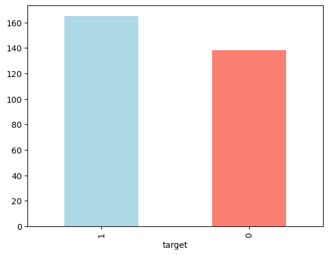

```python
df.target.value_counts().plot(kind='bar',color=["lightblue", "salmon"]);
```

Looking at a quick insight of the dataframe :-

```python
df.info()
```

```
<class 'pandas.core.frame.DataFrame'>
RangeIndex: 303 entries, 0 to 302
Data columns (total 14 columns):
 #   Column    Non-Null Count  Dtype
---  ------    --------------  -----
 0   age       303 non-null    int64
 1   sex       303 non-null    int64
 2   cp        303 non-null    int64
 3   trestbps  303 non-null    int64
 4   chol      303 non-null    int64
 5   fbs       303 non-null    int64
 6   restecg   303 non-null    int64
 7   thalach   303 non-null    int64
 8   exang     303 non-null    int64
 9   oldpeak   303 non-null    float64
 10  slope     303 non-null    int64
 11  ca        303 non-null    int64
 12  thal      303 non-null    int64
 13  target    303 non-null    int64
dtypes: float64(1), int64(13)
memory usage: 33.3 KB
```

### Data Comparison :-

#### Heart Disease Frequency related to Gender

```python
df.sex.value_counts()
```

```
sex
1    207
0     96
Name: count, dtype: int64
```

There are 207 males and 96 females

crosstabbing sex and target:-

```python
pd.crosstab(df.target, df.sex)
```

| sex target | 0 | 1 |
| --- | --- | --- |
| 0 | 24 | 114 |
| 1 | 72 | 93 |

**Visualising the crosstab**

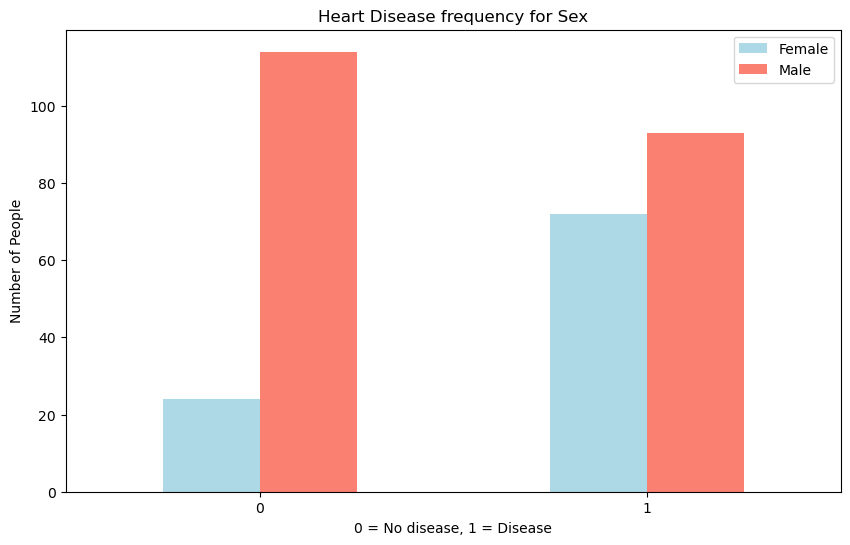

```python
pd.crosstab(df.target,df.sex).plot(kind="bar",
                                   figsize=(10,6),
                                   color=["lightblue","salmon"]);

plt.title("Heart Disease frequency for Sex")
plt.xlabel("0 = No disease, 1 = Disease")
plt.ylabel("Number of People")
plt.legend(["Female", "Male"])
plt.xticks(rotation=0); # making labels on x-axis horizontal
```

#### Age vs Max Heart Rate for Heart Disease

comparing age and max heart rate using a scatter plot.

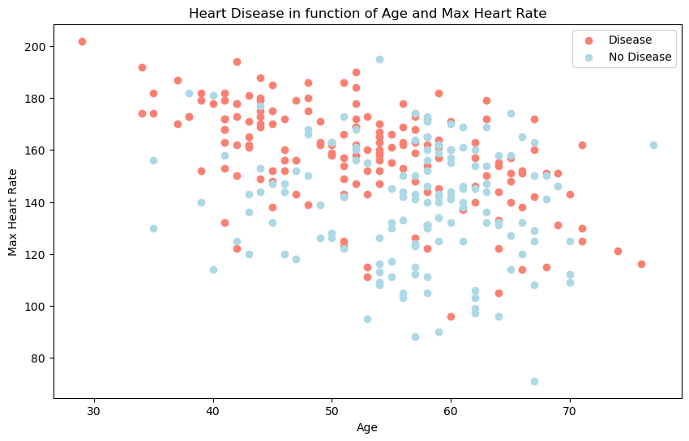

```python
plt.figure(figsize=(10,6))

plt.scatter(df.age[df.target==1],
            df.thalach[df.target==1],
            c="salmon")

plt.scatter(df.age[df.target==0],
            df.thalach[df.target==0],
            c="lightblue")

plt.title("Heart Disease in function of Age and Max Heart Rate")
plt.xlabel("Age")
plt.legend(["Disease","No Disease"])
plt.ylabel("Max Heart Rate");
```

#### Checking the age Distribution

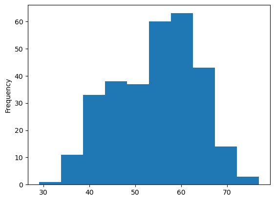

```python
df.age.plot.hist();
```

#### Heart Disease frequency per Chest Pain Type

```python
pd.crosstab(df.cp, df.target)
```

| target cp | 0 | 1 |
| --- | --- | --- |
| 0 | 104 | 39 |
| 1 | 9 | 41 |
| 2 | 18 | 69 |
| 3 | 7 | 16 |

**Visualising the crosstab**

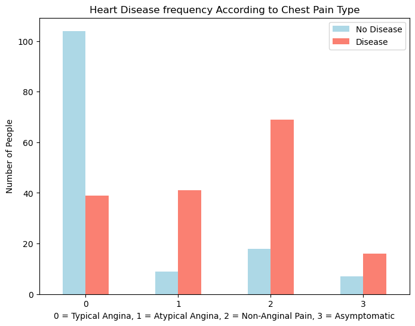

```python
pd.crosstab(df.cp,df.target).plot(kind="bar",
                                  figsize=(8,6),
                                  color=["lightblue","salmon"]);

plt.title("Heart Disease frequency According to Chest Pain Type")
plt.legend(["No Disease", "Disease"])
plt.xlabel("0 = Typical Angina, 1 = Atypical Angina, 2 = Non-Anginal Pain, 3 = Asymptomatic")
plt.ylabel("Number of People")
plt.xticks(rotation=0);
```

#### Correlation Between Independent Variables

```python
corr_matrix = df.corr()
corr_matrix
```

|  | age | sex | cp | trestbps | chol | fbs | restecg | thalach | exang | oldpeak | slope | ca | thal | target |
| --- | --- | --- | --- | --- | --- | --- | --- | --- | --- | --- | --- | --- | --- | --- |
| age | 1.000000 | -0.098447 | -0.068653 | 0.279351 | 0.213678 | 0.121308 | -0.116211 | -0.398522 | 0.096801 | 0.210013 | -0.168814 | 0.276326 | 0.068001 | -0.225439 |
| sex | -0.098447 | 1.000000 | -0.049353 | -0.056769 | -0.197912 | 0.045032 | -0.058196 | -0.044020 | 0.141664 | 0.096093 | -0.030711 | 0.118261 | 0.210041 | -0.280937 |
| cp | -0.068653 | -0.049353 | 1.000000 | 0.047608 | -0.076904 | 0.094444 | 0.044421 | 0.295762 | -0.394280 | -0.149230 | 0.119717 | -0.181053 | -0.161736 | 0.433798 |
| trestbps | 0.279351 | -0.056769 | 0.047608 | 1.000000 | 0.123174 | 0.177531 | -0.114103 | -0.046698 | 0.067616 | 0.193216 | -0.121475 | 0.101389 | 0.062210 | -0.144931 |
| chol | 0.213678 | -0.197912 | -0.076904 | 0.123174 | 1.000000 | 0.013294 | -0.151040 | -0.009940 | 0.067023 | 0.053952 | -0.004038 | 0.070511 | 0.098803 | -0.085239 |
| fbs | 0.121308 | 0.045032 | 0.094444 | 0.177531 | 0.013294 | 1.000000 | -0.084189 | -0.008567 | 0.025665 | 0.005747 | -0.059894 | 0.137979 | -0.032019 | -0.028046 |
| restecg | -0.116211 | -0.058196 | 0.044421 | -0.114103 | -0.151040 | -0.084189 | 1.000000 | 0.044123 | -0.070733 | -0.058770 | 0.093045 | -0.072042 | -0.011981 | 0.137230 |
| thalach | -0.398522 | -0.044020 | 0.295762 | -0.046698 | -0.009940 | -0.008567 | 0.044123 | 1.000000 | -0.378812 | -0.344187 | 0.386784 | -0.213177 | -0.096439 | 0.421741 |
| exang | 0.096801 | 0.141664 | -0.394280 | 0.067616 | 0.067023 | 0.025665 | -0.070733 | -0.378812 | 1.000000 | 0.288223 | -0.257748 | 0.115739 | 0.206754 | -0.436757 |
| oldpeak | 0.210013 | 0.096093 | -0.149230 | 0.193216 | 0.053952 | 0.005747 | -0.058770 | -0.344187 | 0.288223 | 1.000000 | -0.577537 | 0.222682 | 0.210244 | -0.430696 |
| slope | -0.168814 | -0.030711 | 0.119717 | -0.121475 | -0.004038 | -0.059894 | 0.093045 | 0.386784 | -0.257748 | -0.577537 | 1.000000 | -0.080155 | -0.104764 | 0.345877 |
| ca | 0.276326 | 0.118261 | -0.181053 | 0.101389 | 0.070511 | 0.137979 | -0.072042 | -0.213177 | 0.115739 | 0.222682 | -0.080155 | 1.000000 | 0.151832 | -0.391724 |
| thal | 0.068001 | 0.210041 | -0.161736 | 0.062210 | 0.098803 | -0.032019 | -0.011981 | -0.096439 | 0.206754 | 0.210244 | -0.104764 | 0.151832 | 1.000000 | -0.344029 |
| target | -0.225439 | -0.280937 | 0.433798 | -0.144931 | -0.085239 | -0.028046 | 0.137230 | 0.421741 | -0.436757 | -0.430696 | 0.345877 | -0.391724 | -0.344029 | 1.000000 |

plotting the correlation matrix :-

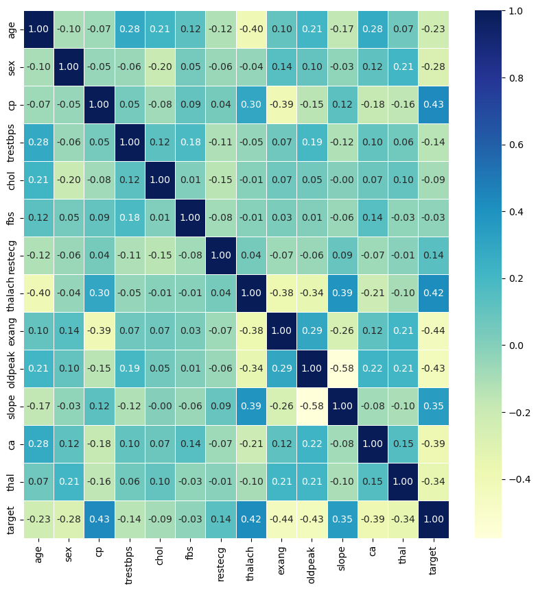

```python
plt.figure(figsize=(10,10))
sns.heatmap(corr_matrix,
           annot=True,
           linewidths=0.5,
           fmt=".2f",
           cmap="YlGnBu");
```

## 7. Modeling

```python
df.head()
```

|  | age | sex | cp | trestbps | chol | fbs | restecg | thalach | exang | oldpeak | slope | ca | thal | target |
| --- | --- | --- | --- | --- | --- | --- | --- | --- | --- | --- | --- | --- | --- | --- |
| 0 | 63 | 1 | 3 | 145 | 233 | 1 | 0 | 150 | 0 | 2.3 | 0 | 0 | 1 | 1 |
| 1 | 37 | 1 | 2 | 130 | 250 | 0 | 1 | 187 | 0 | 3.5 | 0 | 0 | 2 | 1 |
| 2 | 41 | 0 | 1 | 130 | 204 | 0 | 0 | 172 | 0 | 1.4 | 2 | 0 | 2 | 1 |
| 3 | 56 | 1 | 1 | 120 | 236 | 0 | 1 | 178 | 0 | 0.8 | 2 | 0 | 2 | 1 |
| 4 | 57 | 0 | 0 | 120 | 354 | 0 | 1 | 163 | 1 | 0.6 | 2 | 0 | 2 | 1 |

Splitting the target variable in the dataframe from the rest :-

```python
X = df.drop("target", axis=1)
y = df.target.values
```

```python
X.head()
```

|  | age | sex | cp | trestbps | chol | fbs | restecg | thalach | exang | oldpeak | slope | ca | thal |
| --- | --- | --- | --- | --- | --- | --- | --- | --- | --- | --- | --- | --- | --- |
| 0 | 63 | 1 | 3 | 145 | 233 | 1 | 0 | 150 | 0 | 2.3 | 0 | 0 | 1 |
| 1 | 37 | 1 | 2 | 130 | 250 | 0 | 1 | 187 | 0 | 3.5 | 0 | 0 | 2 |
| 2 | 41 | 0 | 1 | 130 | 204 | 0 | 0 | 172 | 0 | 1.4 | 2 | 0 | 2 |
| 3 | 56 | 1 | 1 | 120 | 236 | 0 | 1 | 178 | 0 | 0.8 | 2 | 0 | 2 |
| 4 | 57 | 0 | 0 | 120 | 354 | 0 | 1 | 163 | 1 | 0.6 | 2 | 0 | 2 |

```python
y
```

```
array([1, 1, 1, 1, 1, 1, 1, 1, 1, 1, 1, 1, 1, 1, 1, 1, 1, 1, 1, 1, 1, 1,
       1, 1, 1, 1, 1, 1, 1, 1, 1, 1, 1, 1, 1, 1, 1, 1, 1, 1, 1, 1, 1, 1,
       1, 1, 1, 1, 1, 1, 1, 1, 1, 1, 1, 1, 1, 1, 1, 1, 1, 1, 1, 1, 1, 1,
       1, 1, 1, 1, 1, 1, 1, 1, 1, 1, 1, 1, 1, 1, 1, 1, 1, 1, 1, 1, 1, 1,
       1, 1, 1, 1, 1, 1, 1, 1, 1, 1, 1, 1, 1, 1, 1, 1, 1, 1, 1, 1, 1, 1,
       1, 1, 1, 1, 1, 1, 1, 1, 1, 1, 1, 1, 1, 1, 1, 1, 1, 1, 1, 1, 1, 1,
       1, 1, 1, 1, 1, 1, 1, 1, 1, 1, 1, 1, 1, 1, 1, 1, 1, 1, 1, 1, 1, 1,
       1, 1, 1, 1, 1, 1, 1, 1, 1, 1, 1, 0, 0, 0, 0, 0, 0, 0, 0, 0, 0, 0,
       0, 0, 0, 0, 0, 0, 0, 0, 0, 0, 0, 0, 0, 0, 0, 0, 0, 0, 0, 0, 0, 0,
       0, 0, 0, 0, 0, 0, 0, 0, 0, 0, 0, 0, 0, 0, 0, 0, 0, 0, 0, 0, 0, 0,
       0, 0, 0, 0, 0, 0, 0, 0, 0, 0, 0, 0, 0, 0, 0, 0, 0, 0, 0, 0, 0, 0,
       0, 0, 0, 0, 0, 0, 0, 0, 0, 0, 0, 0, 0, 0, 0, 0, 0, 0, 0, 0, 0, 0,
       0, 0, 0, 0, 0, 0, 0, 0, 0, 0, 0, 0, 0, 0, 0, 0, 0, 0, 0, 0, 0, 0,
       0, 0, 0, 0, 0, 0, 0, 0, 0, 0, 0, 0, 0, 0, 0, 0, 0], dtype=int64)
```

### Splitting The Data into Train and Test Sets

```python
np.random.seed(42)

X_train, X_test, y_train, y_test = train_test_split(X,y,test_size=0.2) # 80% training set and 20% test set
```

### Model Selection

In this experiment we are going to use three classical algorithms suggested by the Scikit-learn algorithm cheat sheet.

We are going to use :-

1. Logistic Regression
2. K Nearest Neighbors Classifier
3. Random Forest Classifier

```python
models = {
    "KNN" : KNeighborsClassifier(),
    "Logistic Regression" : LogisticRegression(),
    "Random Forest" : RandomForestClassifier()
}

# Creating a function to fit and score the models

def fit_and_score(models,X_train,X_test, y_train,y_test):
    """
    Fits and evaluates given machine learning models.
    models : a dict of differend sklearn machine learning models.
    X_train : training data
    X_test : testing data
    y_train : labels associated with the training data
    y_test : labels associated with the testing data
    """
    np.random.seed(42)
    model_scores = {}
    for name, model in models.items():
        model.fit(X_train, y_train)
        model_scores[name] = model.score(X_test, y_test)
    return model_scores
```

```python
model_scores = fit_and_score(models=models,
                             X_train=X_train,
                             X_test=X_test,
                             y_train=y_train,
                             y_test=y_test)

model_scores
```

```
{'KNN': 0.6885245901639344,
 'Logistic Regression': 0.8852459016393442,
 'Random Forest': 0.8360655737704918}
```

### Model Comparison

First, Let us convert the model comparison into a dataframe.

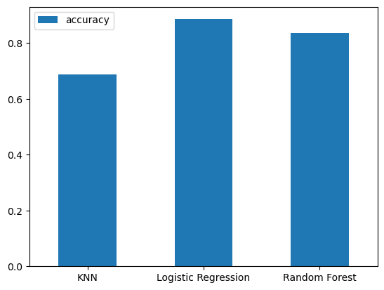

```python
model_compare = pd.DataFrame(model_scores, index=["accuracy"])
model_compare.T.plot.bar();
plt.xticks(rotation=0);
plt.legend(loc="upper left");
```

Further evaluation of the models will be done in the next section.

## 8. Model Evaluation

First let us examine each model in greater detail.

### Preparing The Classification Report for each model

```python
reports = []
for name, model in models.items():
    print("\033[1m" + name + "\033[0m\n")
    reports.append(pd.DataFrame(classification_report(y_test, model.predict(X_test),output_dict=True)))
    print(classification_report(y_test, model.predict(X_test)) + "\n")
```

```
KNN

              precision    recall  f1-score   support

           0       0.69      0.62      0.65        29
           1       0.69      0.75      0.72        32

    accuracy                           0.69        61
   macro avg       0.69      0.69      0.69        61
weighted avg       0.69      0.69      0.69        61


Logistic Regression

              precision    recall  f1-score   support

           0       0.89      0.86      0.88        29
           1       0.88      0.91      0.89        32

    accuracy                           0.89        61
   macro avg       0.89      0.88      0.88        61
weighted avg       0.89      0.89      0.89        61


Random Forest

              precision    recall  f1-score   support

           0       0.83      0.83      0.83        29
           1       0.84      0.84      0.84        32

    accuracy                           0.84        61
   macro avg       0.84      0.84      0.84        61
weighted avg       0.84      0.84      0.84        61
```

**What do these metrics mean?**

**accuracy score :-** The rate at which the set of labels predicted for a sample must exactly match the corresponding set of labels in y_true.

**precision score :-** The precision is the ratio `tp / (tp + fp)` where `tp` is the number of true positives and `fp` the number of false positives. The precision is intuitively the ability of the classifier not to label as positive a sample that is negative.

**recall score :-** The recall is the ratio `tp / (tp + fn)` where `tp` is the number of true positives and `fn` the number of false negatives. The recall is intuitively the ability of the classifier to find all the positive samples.

**f1 score :-** The F1 score can be interpreted as a harmonic mean of the precision and recall, where an F1 score reaches its best value at 1 and worst score at 0.

**support :-** The support is the number of occurrences of each class in y_true.

**macro average :-** The arithmetic mean of the scores of each class.

**weighted average :-** The mean of the scores of each class considering the weight of each class.

Now visualising the classification report :-

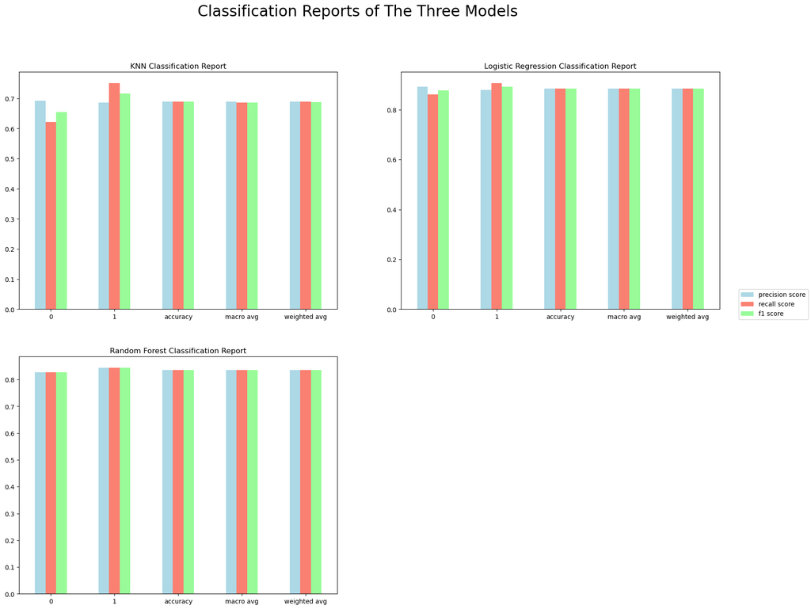

```python
fig,ax =plt.subplots(nrows=2, ncols=2, figsize=(20,15))
reports[0].T.drop(["support"], axis=1).plot.bar(color=["lightblue", "salmon", "palegreen"],ax=ax[0,0], legend= False)
reports[1].T.drop(["support"], axis=1).plot.bar(color=["lightblue", "salmon", "palegreen"],ax=ax[0,1], legend = False)
reports[2].T.drop(["support"], axis=1).plot.bar(color=["lightblue", "salmon", "palegreen"],ax=ax[1,0], legend = False)

ax[1,1].set_visible(False)

labels = ["precision score", "recall score", "f1 score"]
fig.suptitle("Classification Reports of The Three Models", fontsize=24)
fig.legend(labels,loc="center right")

model_names = []
for name in models.keys():
    model_names.append(name)

p = 0
for i in range(0,2):
    for j in range (0,2):
        ax[i,j].tick_params(labelrotation=0)
        if(p != 3):
            ax[i,j].title.set_text(model_names[p] + " Classification Report")
            p+=1
```

## 9. Improving The Model by Tuning the Hyperparameters

Attempting to improve the scores of the model by the process of tuning the hyperparameters.

### Improving the K Nearest Neighbors by Tuning the Hyperparameters by Hand

Let us first look at the hyperparameters of the KNN model

```python
models["KNN"].get_params() # looking at the hyperparameters for this model
```

```
{'algorithm': 'auto',
 'leaf_size': 30,
 'metric': 'minkowski',
 'metric_params': None,
 'n_jobs': None,
 'n_neighbors': 5,
 'p': 2,
 'weights': 'uniform'}
```

`n_neighbors` or number of neighbors is one of the main hyperparameters of this model. Let us observe the variation on model scores based on the number of neighbours

```python
train_scores = []
test_scores = []

neighbors = range(1,21)

knn = KNeighborsClassifier()

for i in neighbors:
    knn.set_params(n_neighbors=i)

    knn.fit(X_train,y_train)

    train_scores.append(knn.score(X_train, y_train))
    test_scores.append(knn.score(X_test,y_test))
```

Visualising the data :-

```
Maximum KNN score on the test data: 75.41%
```

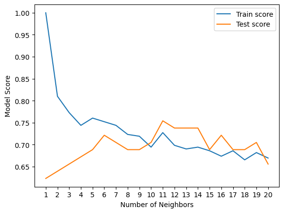

```python
plt.plot(neighbors, train_scores, label="Train score")
plt.plot(neighbors, test_scores, label="Test score")
plt.xticks(np.arange(1, 21, 1))
plt.xlabel("Number of Neighbors")
plt.ylabel("Model Score")
plt.legend()

print(f"Maximum KNN score on the test data: {max(test_scores)*100:.2f}%")
```

Looking at the plot, it is safe to say that `n_neighbors = 11` is the best option for this model.

However, since the scores of this model are no where close to those of LogisticRegression and RandomForestClassifier, this model is being discarded.

### Improving The Logistic Regression Model and The Random Forest Classifier Model using `RandomizedSearchCV`

```python
models["Logistic Regression"].get_params() # looking at the hyperparameters of logistic regression model
```

```
{'C': 1.0,
 'class_weight': None,
 'dual': False,
 'fit_intercept': True,
 'intercept_scaling': 1,
 'l1_ratio': None,
 'max_iter': 100,
 'multi_class': 'auto',
 'n_jobs': None,
 'penalty': 'l2',
 'random_state': None,
 'solver': 'lbfgs',
 'tol': 0.0001,
 'verbose': 0,
 'warm_start': False}
```

```python
models["Random Forest"].get_params()
```

```
{'bootstrap': True,
 'ccp_alpha': 0.0,
 'class_weight': None,
 'criterion': 'gini',
 'max_depth': None,
 'max_features': 'sqrt',
 'max_leaf_nodes': None,
 'max_samples': None,
 'min_impurity_decrease': 0.0,
 'min_samples_leaf': 1,
 'min_samples_split': 2,
 'min_weight_fraction_leaf': 0.0,
 'n_estimators': 100,
 'n_jobs': None,
 'oob_score': False,
 'random_state': None,
 'verbose': 0,
 'warm_start': False}
```

```python
logistic_regression_grid = {
    "C" : np.logspace(-4,4,20),
    "solver" : ["liblinear"]
}

random_forest_grid = {
    "n_estimators" : np.arange(10,1000,50),
    "max_depth" : [None,3,5,10],
    "min_samples_split" : np.arange(2,20,2),
    "min_samples_leaf" : np.arange(1,20,2)
}
```

```python
np.random.seed(42)

rs_log_reg = RandomizedSearchCV(LogisticRegression(),
                                param_distributions=logistic_regression_grid,
                                cv=5,
                                n_iter=20,
                                verbose=True)

rs_log_reg.fit(X_train,y_train);
```

```
Fitting 5 folds for each of 20 candidates, totalling 100 fits
```

```python
rs_log_reg.best_params_
```

```
{'solver': 'liblinear', 'C': 0.23357214690901212}
```

```python
rs_log_reg.score(X_test,y_test)
```

```
0.8852459016393442
```

Now, following the same procedure for random forest classifier

```python
np.random.seed(42)

rs_random_forest = RandomizedSearchCV(RandomForestClassifier(),
                                      param_distributions=random_forest_grid,
                                      cv=5,
                                     n_iter=20,
                                     verbose=True)

rs_random_forest.fit(X_train,y_train);
```

```
Fitting 5 folds for each of 20 candidates, totalling 100 fits
```

```python
rs_random_forest.best_params_
```

```
{'n_estimators': 210,
 'min_samples_split': 4,
 'min_samples_leaf': 19,
 'max_depth': 3}
```

```python
rs_random_forest.score(X_test, y_test)
```

```
0.8688524590163934
```

### Further Improving The `LogisticRegression` Model Using `GridSearchCV`

```python
logistic_regression_grid = {
    "C" : np.logspace(-4,4,20),
    "solver" : ["liblinear"]
}

gs_logistic_reg = GridSearchCV(LogisticRegression(),
                               param_grid=logistic_regression_grid,
                               cv=5,
                               verbose=True)

gs_logistic_reg.fit(X_train,y_train);
```

```
Fitting 5 folds for each of 20 candidates, totalling 100 fits
```

```python
gs_logistic_reg.best_params_
```

```
{'C': 0.23357214690901212, 'solver': 'liblinear'}
```

```python
gs_logistic_reg.score(X_test, y_test)
```

```
0.8852459016393442
```

```python
# looking at the predictions made by our model

y_preds = gs_logistic_reg.predict(X_test)
y_preds
```

```
array([0, 1, 1, 0, 1, 1, 1, 0, 0, 1, 1, 0, 1, 0, 1, 1, 1, 0, 0, 0, 1, 0,
       0, 1, 1, 1, 1, 1, 0, 1, 0, 0, 0, 0, 1, 0, 1, 1, 1, 1, 1, 1, 1, 1,
       1, 0, 1, 1, 0, 0, 0, 0, 1, 1, 0, 0, 0, 1, 0, 0, 0], dtype=int64)
```

```python
y_test
```

```
array([0, 0, 1, 0, 1, 1, 1, 0, 0, 1, 1, 1, 1, 0, 1, 1, 1, 0, 0, 0, 1, 0,
       0, 1, 1, 0, 0, 1, 0, 1, 1, 0, 0, 1, 1, 0, 1, 1, 1, 1, 1, 1, 1, 1,
       1, 0, 0, 1, 0, 0, 0, 0, 1, 1, 0, 0, 0, 1, 0, 0, 0], dtype=int64)
```

## 10. Evaluating The Improved Model Beyond Accuracy

Now let us evaluate the model by using ROC curve, confusion matrix and classification report.

### Preparing the ROC Curve and AUC Scores

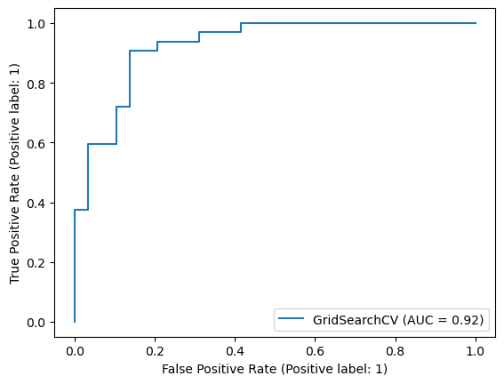

```python
RocCurveDisplay.from_estimator(estimator=gs_logistic_reg,
                               X=X_test,
                               y=y_test);
```

### Confusion Matrix

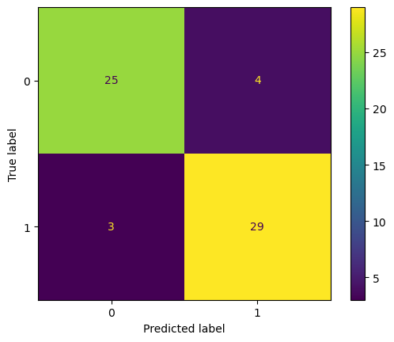

```python
ConfusionMatrixDisplay.from_predictions(y_true=y_test, y_pred=y_preds);
```

### Classification Report

```python
print(classification_report(y_test, y_preds))
```

```
              precision    recall  f1-score   support

           0       0.89      0.86      0.88        29
           1       0.88      0.91      0.89        32

    accuracy                           0.89        61
   macro avg       0.89      0.88      0.88        61
weighted avg       0.89      0.89      0.89        61
```

Since only a single training and test set was used on the model, let us observe how our model performs with cross validation and different scoring parameters.

```python
gs_logistic_reg.best_params_
```

```
{'C': 0.23357214690901212, 'solver': 'liblinear'}
```

```python
clf = LogisticRegression(C=0.23357214690901212, solver="liblinear")
```

```python
cv_acc = cross_val_score(clf,
                         X,
                         y,
                         cv=5,
                         scoring="accuracy")

cv_acc
```

```
array([0.81967213, 0.90163934, 0.8852459 , 0.88333333, 0.75      ])
```

By considering the average,

```python
cv_acc = np.mean(cv_acc)

cv_acc
```

```
0.8479781420765027
```

Following the same procedure for other classification report metrics,

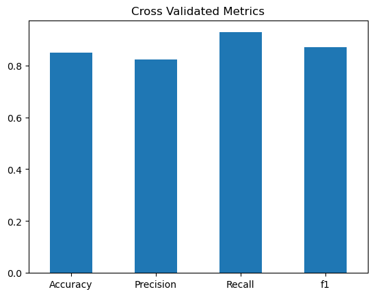

```python
cv_precision = np.mean(cross_val_score(clf,X,y,cv=5,scoring="precision"))

cv_recall = np.mean(cross_val_score(clf,X,y,cv=5,scoring="recall"))

cv_f1 = np.mean(cross_val_score(clf,X,y,cv=5,scoring="f1"))

cv_metrics = {
    "Accuracy" : cv_acc,
    "Precision" : cv_precision,
    "Recall" : cv_recall,
    "f1" : cv_f1
}

cv_metrics = pd.DataFrame(cv_metrics, index=[0])

cv_metrics.T.plot.bar(title="Cross Validated Metrics", legend=False);
plt.xticks(rotation=0);
```

### Feature Importance

This can help us find the contribution factor of each feature which effects the outcome.

```python
clf.fit(X_train,y_train)
features_dict = dict(zip(df.columns, list(clf.coef_[0])))
features_dict
```

```
{'age': 0.003699220218693,
 'sex': -0.9042408909021112,
 'cp': 0.6747282639169492,
 'trestbps': -0.01161340193177967,
 'chol': -0.001703644306964925,
 'fbs': 0.047876883381437196,
 'restecg': 0.33490194499930287,
 'thalach': 0.024729383642503815,
 'exang': -0.6312040482089574,
 'oldpeak': -0.5759093926828687,
 'slope': 0.470951337854335,
 'ca': -0.651653485595126,
 'thal': -0.6998420593767237}
```

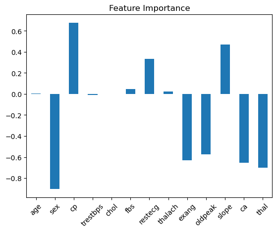

```python
pd.DataFrame(features_dict, index=[0]).T.plot.bar(title="Feature Importance", legend=False);
plt.xticks(rotation=45);
```

As the graph indicates, more positive the bar, the more that feature contributes towards the model's decision.

the negative values indicate that there is a negative correlation between the feature and the model's decision.